# Projet IF36 - Analyse des données de Kickstarter

##### L’utilisation de mots émotionnels ou marketing dans le titre est-elle corrélée avec un meilleur taux de succès ?

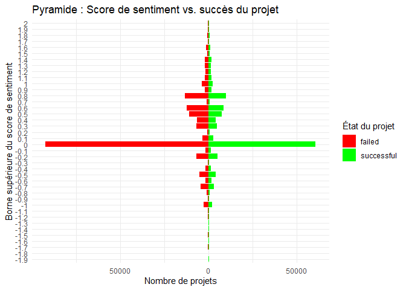

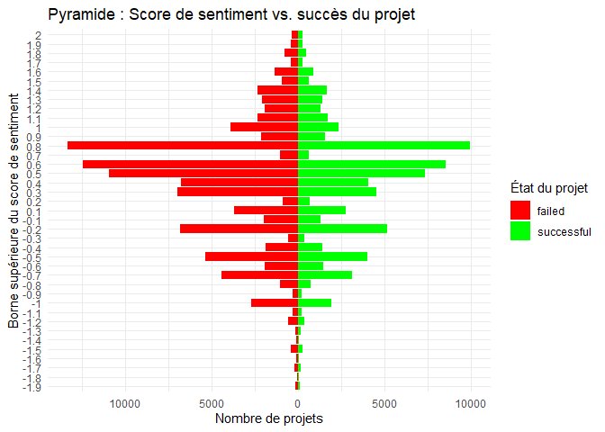

Ce graphique illustre la corrélation entre le sentiment des titres des projets Kickstarter (mesuré par la méthode Syuzhet, de -2 à 2) et leur succès, distinguant les projets “Échoués” (rouge) et “Réussis” (vert).

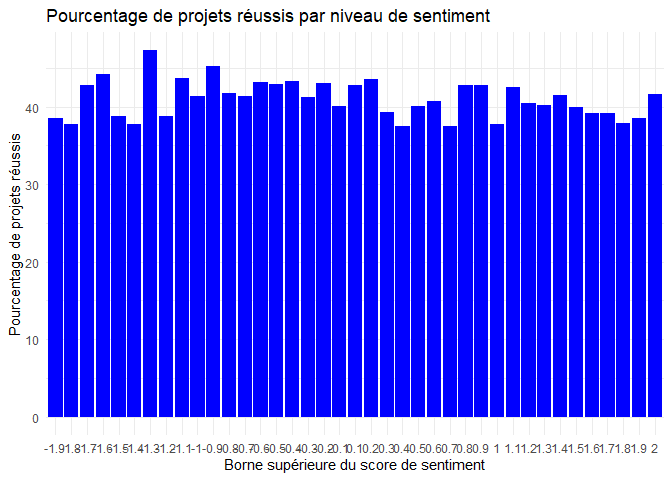

On observe que la plupart des projets, qu’ils aient réussi ou échoué, ont un score de sentiment proche de 0 (neutre), avec un pic marqué à cette valeur. Cette analyse suggère que le sentiment du titre n’influence que marginalement le succès d’un projet, confirmant que d’autres facteurs pourraient jouer un rôle plus déterminant dans les résultats des campagnes Kickstarter.

#### QUESTION 6 : Dans quelle mesure le montant de l’objectif influence-t-il la probabilité de succès d’une campagne ?

On se demande si le montant demandé lors d’une campagne influence la réussite. On peut se demander si un projet qui demande une somme importante a peu de chance de réussir et inversement si un projet qui demande un budget faible a plus de chance de réussir.

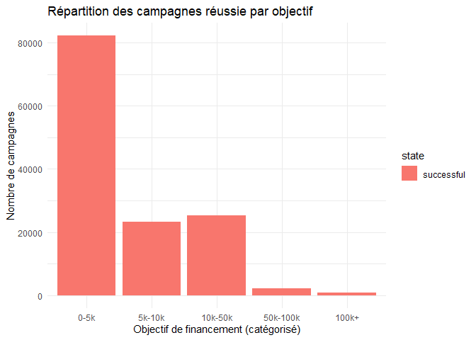

Il y a plus de chance de réussir un projet avec une somme inférieur a 5 000 est du au nombre de projet qui sont plus nombreux dans ces tranches ? On va donc regarder le taux de réussite par tranche.

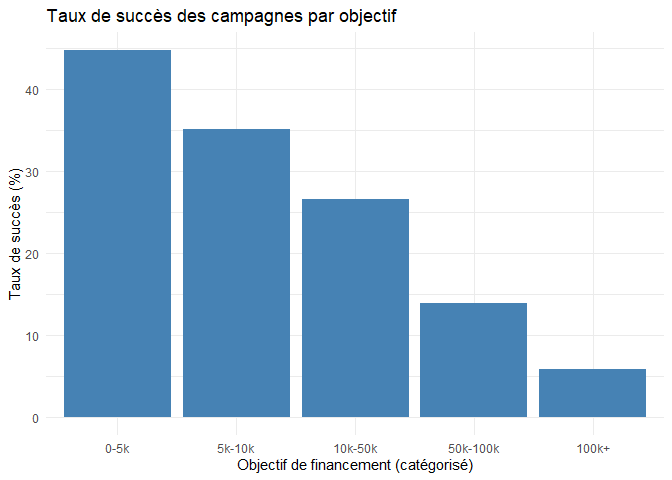

On remarque que le taux de réussite est décroissant au fur est à mesure des tranches. On commence avec presque 45% de réussite pour des montants inférieurs à 5 000 à moins de 10% pour les plus de 100 000 demandés. Mais pourquoi les projets avec une demande de plus petit budget réussisse mieux alors ? Cela peut être dû à un facteur psychologique. Les personnes qui voient une grosse somme demandés se disent inconsciemment que le projet va jamais atteindre ses objectifs. Inversement, si on demande une petite somme, les donnateurs vont avoir l’impression que le projet est plus réalisable.

## Conclusions

### Conclusions de l’analyse graphique

Dans le cadre de notre analyse, nous avons pu dégager des facteurs déterminants qui semblent avoir un impact important dans la réussite ou l’échec d’un projet Kickstarter.

Un motif qui se dessine tout au long de notre analyse est l’enjeu central du **montant demandé** sur la réussite d’un projet.

Comme nous avons pu le démontrer dans l’analyse exploratoire mais également dans la partie dédiée aux montants demandé, un **montant demandé faible est un facteur de réussite**, là où un montant demandé élevé est fortement corrélé à un échec.

On peut relier cela à l’effet psychologique que peut avoir un montant demandé démesuré sur le financeur potentiel: L’objectif peut lui paraître irréaliste et sa contribution peut paraître dérisoire par rapport au montant à atteindre. La quantité de contributeurs requis peut également créer une dilution de la responsabilité.

Au contraire, une campagne à l’objectif modeste permet à chaque contributeur de ressentir qu’il fait une différence visible, et de voir des réussites beaucoup plus rapidement. Les paliers supplémentaires réguliers ajoutés par les créateurs du projet permettent aux contributeurs de participer à des petites victoires, même après que l’objectif principal soit atteint.

On remarque que les **catégories** avec le meilleur taux de réussite (comme **Dance**, **Theater** et **Comics**) sont des catégories où les montants demandés sont relativement modestes. On observe une corrélation du montant demandé avec le taux de réussite. Il y a cependant des exceptions, comme la catégorie **Journalism** qui affiche un taux de réussite relativement bas par rapport à ses objectifs plutôt modestes.

Une analyse des **pays** de domiciliation les plus avantageux permet de dégager 3 pays très favorisés: Les **Etats-Unis**, le **Royaume-Uni** et **Hong Kong**. Les deux premiers sont ceux où Kickstarter a bénéficié d’une grande avance sur le marché du financement participatif. Dans d’autres pays, d’autres plate-formes ont pu capter le marché avant Kickstarter.

Pour ce qui est de la **variable temporelle**, une stratégie **optimale** se dessine: Il ne faut pas lancer son projet en décembre ou en juillet-aout, où les dépenses sont généralement très hautes. La durée optimale d’une campagne se situe entre 20 et 30 jours, il faut au maximum éviter de la rallonger pour tirer profit de l’impression d’urgence et créer un moment de forte attention autour de son projet.

Enfin, d’après notre analyse, il est inutile de charger son projet de **mots sensationnalistes** et émotionnellement chargés. En effet, ceux-ci ne semblent pas avoir d’impact sur la réussite du projet.

Grâce à notre analyse graphique, nous avons pu déceler des facteurs clés permettant d’expliquer la réussite ou l’échecs des projets Kickstarter.

### Compétences acquises et perspectives des membres

- **Florian BONELLI** : De ce projet, il en ressort que la qualité des données, introduites par un filtrage (notamment en rejetant les valeurs extrêmes), permet d’obtenir des visualisations plus explicites et pertinentes. Il aurait été intéressant de se rendre sur les projets ayant atteint leurs objectifs respectifs, pour approfondir notre analyse du projet et donc estimer de combien il faudrait ajuster à la baisse l’objectif initial pour maximiser nos chances de succès.
- **Eyvan FAURE** : J’ai principalement appris l’importance de l’esthétique dans les visualisations, car c’est un facteur déterminant pour une compréhension plus rapide et instinctive des visualisations. Je pense qu’il aurait été intéressant d’aborder dans notre projet l’utilisation du logiciel Tableau plus en profondeur car il semble très pertinent pour notre projet je trouve donc j’aurais aimé avoir plus de temps pour l’approfondir davantage.
- **Ryan OUYED** : Dans le cadre de ce projet, j’ai pu apprendre l’importance d’avoir un jeu de donnée exploitable et propre. En effet, les quelques incohérences et corruptions trouvables dans le jeu de données de base nous ont fait nous poser des questions sur la validité de nos analyses. On constate ici l’importance d’une bonne collecte des données. J’ai également pu constater les complications de traiter un jeu de données avec beaucoup de valeurs extrêmes (Montants élevés, prédominance des USA) qui m’a beaucoup fait réfléchir sur la façon de représenter des grandes disparités dans un espace limité.
- **Lucas SAURON** : Ce projet m’a permis de prendre conscience de l’utilité d’explorer les données sans idée préconçue dans un premier temps. Cette approche permet souvent de faire émerger des tendances ou des éléments inattendus, que l’on n’aurait pas remarqués autrement. J’ai également compris l’importance de bien choisir le type de graphique en fonction de ce que l’on souhaite mettre en avant. Il existe une grande variété de visualisations, souvent méconnues, qui peuvent grandement améliorer la clarté et la pertinence d’une analyse si elles sont bien utilisées.

## Annexe

### Répartition des tâches au sein de l’équipe

**Florian BONELLI** :

- Question 3 (Périodes de l’année)
- Question 4 (Montants)
- Diaporama

**Eyvan FAURE** :

- Nettoyage des données
- Question 1 (Catégories)
- Shiny Dashboard
- Tableau
- Diaporama

**Ryan OUYED** :

- Présentation du dataset
- Analyses Exploratoires
- Question 2 (Pays)
- Diaporama

**Lucas SAURON** :

- Question 5 (Mots utilisés)
- Diaporama